# Alexandrov-SocialSelfMotivesWOM-2013-JAMS.pdf

Converted from PDF `Alexandrov-SocialSelfMotivesWOM-2013-JAMS.pdf` · 16 pages · anchors: page `#pN`, block `#pN-bK`

Page 1

ORIGINAL EMPIRICAL RESEARCH

## The effects of social- and self-motives on the intentions to share positive and negative word of mouth

Aliosha Alexandrov & Bryan Lilly & Emin Babakus

Received: 10 February 2012 /Accepted: 6 December 2012 /Published online: 5 January 2013 # Academy of Marketing Science 2013

Abstract We examine social- and self-motives as drivers of Word of Mouth (WOM). The main proposition is that the transmitter expects to gain personal and social benefits from sharing his opinion about a brand. The gains are in the form of expected satisfaction of self- and social-needs. In the research model, self-needs (i.e., self-enhancement and selfaffirmation) are considered the initial driver of WOM. The desire for their satisfaction through WOM results in an intended social interaction, which in turn triggers socialmotives: social-needs (i.e., social comparison and social bonding) and social-intentions (i.e., helping others and providing social information). WOM is the outcome of the intention to engage in a social interaction that is initiated by the intention to satisfy self-needs. Through an empirical analysis, we examine how the underlying mechanism varies for positive and negative WOM. Positive WOM is motivated primarily by the need for self-enhancement, and negative WOM is motivated by the need for self-affirmation. The need for social comparison affects both valences of WOM, the need for social bonding affects only positive WOM, and intention to help others and share social information affect only negative WOM. The findings suggest that discussing brands can be a mechanism for acquiring personal and

social benefits, and consequently, promotional campaigns should highlight the gains customers accrue through WOM.

Keywords Word-of-mouth <sup>.</sup>Social-needs <sup>.</sup>Self-needs <sup>.</sup> Social comparison <sup>.</sup>Social bonding <sup>.</sup>Helping behavior <sup>.</sup> Self-affirmation <sup>.</sup>Self-enhancement

People engage in word of mouth (WOM) for multiple reasons. Most research has approached WOM as a function of brand experiences. Brand-related factors such as satisfaction, loyalty, quality, commitment, trust, and perceived value are important drivers of WOM (de Matos and Rossi 2008). The view that brand experiences drive WOM is logical and managerially important. However, this view does not account for motives outside brand experiences. Researchers have long recognized that factors such as involvement with the self and others drive WOM (Dichter 1966). WOM is affected by emotion (Berger and Milkman 2012) and is used to express achievement, seek confirmation, and achieve a therapeutic feeling (Cheung et al. 2007). WOM entails communal elements (Kozinets et al. 2010). Public visibility and interest (Berger and Schwartz 2011) and motives such as altruism and self-enhancement also drive WOM (Sundaram et al. 1998). These non-brand motivational aspects of WOM have yet to be explored within an integrative framework.

In this study, we examine WOM as a socially embedded process and study it as a component of interaction among people. Based on the social exchange theory (Blau 1986; Emerson 1976), we build and test a model viewing WOM as a currency of exchange that allows the person engaging in WOM to gain personal and social benefits. Specifically, we investigate how self- and social-motives drive the intention to engage in WOM. For example, consumers may watch movies or television shows so they can talk to their friends who also watch these movies or shows, thus strengthening

A. Alexandrov (*)<sup>:</sup> B. Lilly College of Business Administration, University of Wisconsin Oshkosh, Sage Hall 1449, Oshkosh, WI 54901, USA e-mail: alexanda@uwosh.edu

B. Lilly e-mail: lilly@uwosh.edu

E. Babakus Department of Marketing & Supply Chain Management, Fogelman College of Business & Economics, University of Memphis, Memphis, TN 38152, USA e-mail: ebabakus@memphis.edu

J. of the Acad. Mark. Sci. (2013) 41:531–546 DOI 10.1007/s11747-012-0323-4

Page 2

social ties. Customers may brag about a successful purchase they made, or a product they have, to enhance their image. Alternatively, after a bad experience with a brand, people may try to warn others, and through the process defend their harmed self-image.

We posit that the ultimate gain to the transmitter of WOM is the satisfaction of self-needs (i.e., self-enhancement and self-affirmation). However, to satisfy those needs through WOM, a person needs to engage in a social interaction, which entails social considerations. The process of social interaction allows a person to satisfy social-needs: the need to compare themselves with others (Festinger 1954) and to build social ties, which provides a needed sense of belonging (Baumeister and Leary 1995). The satisfaction of socialneeds is, therefore, also a benefit to the transmitter of WOM. In addition, the social interaction process allows the transmitter to approach WOM with two specific intentions relevant to WOM: to help others in their decisions, and to convey social values through their opinions about a brand. These two intentions can be seen as antecedents of WOM and as being able to satisfy the self- and social-needs discussed above. In sum, viewing WOM as a socially embedded process opens a broader perspective for understanding WOM, where the research question changes from “How does a brand affect WOM?” to “What purpose does WOM serve, and how does the underlying motivational process differ between positive and negative WOM?”

The contributions of this study are trifold. First, we illuminate several social aspects of WOM and develop and test a model of the underlying process. Although extant literature provides evidence about self and social factors, much of this literature is contextual and has not been leveraged in a collective manner. Grounded in sound theoretical foundations, the model we advance offers a more complete and inclusive understanding of WOM as a social process. Second, we examine how the model performs when predicting the likelihood to engage in positive versus negative WOM. We find, for example, that social comparison affects both positive and negative WOM, and the rest of the variables have distinct effects. Finally, the study results lend themselves to actionable managerial recommendations. Our findings suggest that the social exchange process of WOM can be used to encourage positive WOM and discourage negative WOM, and that practitioners should develop promotional campaigns by focusing on the benefits customers accrue through social interactions.

In the next section, we review prior research on WOM and summarize key social- and self-related theoretical domains. These domains help us isolate the variables used in the development of the research model. We then test the model empirically and examine how it performs under positive and negative WOM conditions, discuss results, and provide practical recommendations.

Overview of WOM research

Various characteristics of WOM have been studied during the past three decades. WOM is vivid because it often is laden with real personal experiences and feelings (Herr et al. 1991). The valence of WOM, positive versus negative (Richins 1983), and volume (Liu 2006; Wangenheim and Bayon 2004) have strong effects on behavior. Customers with extreme levels of satisfaction or dissatisfaction are more likely to share experiences than customers with neutral opinions (Anderson 1998).

Most WOM research has focused on the experience with the brand and personal characteristics of the transmitter (Anderson 1998; Bowman and Narayandas 2001; Brown et al. 2005; Ladhari 2007; Zeithaml et al. 1996). In a comprehensive meta-analysis based on 127 empirical studies, de Matos and Rossi (2008) identify the most common antecedents of WOM activity (i.e., satisfaction, loyalty, quality, commitment, trust, and perceived value), which demonstrates that, overall, the literature has established a strong link between brand-related experiences and WOM.

Aside from brand experiences, contextual factors also have been discussed in the literature, but to a lesser degree, including: self-enhancement, concern for others, dissonance reduction (Engel et al. 1993; Hennig-Thurau et al. 2004); self-enhancement, altruism, vengeance, and anxiety reduction (Sundaram et al. 1998). Emotion and arousal elicited by the WOM message affect its sharing in online contexts (Berger and Milkman 2012; Berger 2011). Immediate WOM (i.e., shared soon after people learn about or experience a product) is affected by interest, and ongoing WOM (i.e., shared weeks and months later) is affected by public visibility (Berger and Schwartz 2011). Cumulatively, research on contextual factors provides substantial evidence for the importance of non-brand drivers of WOM.

The preceding brief review reveals that although there is extensive literature on WOM, research that examines WOM as a social process is lacking. This is an important gap regarding the fundamental role social processes play at every level of human existence, from an evolutionary standpoint to everyday life. It has been suggested that social needs, rather than survival needs, led to the evolution of human intelligence (Byrne and Whiten 1989; Whiten and Byrne 1997) and that species thrive over time due, in part, to cooperation among members within groups (Nowak 2011). In their everyday lives, people pay close attention to and transmit social information with higher accuracy than nonsocial information (Mesoudi et al. 2006), and up to 70% of daily discussions are dominated by social topics (Dunbar et al. 1997; Emler 1992, 1994). The lack of attention to the social aspect of WOM could be due to its implicit nature; social considerations often are activated automatically by the mere presence of others (Bargh and Chartrand 1999;

532 J. of the Acad. Mark. Sci. (2013) 41:531–546

Page 3

Blair 2002; Litman and Pezzo 2005). In regard to WOM, people share brand experiences in social situations, and they find ways to fit discussions of brands within the existing social dynamics. The model we develop in the following section examines WOM as a social interaction process.

Research model and hypotheses

The research model we advance and test is presented in Fig. 1. It can be viewed as a general model of dialogic discourse between people. As shown in Fig. 1, we argue that self-needs (self-enhancement and self-affirmation) constitute the most basic human needs associated with WOM, which give rise to social-needs such as the need for social comparison and social bonding. These intermediate level social-needs mediate the effects of self-needs on the more concrete and action oriented motives such as sharing social information and helping others. The latter motives are much more concrete and event focused, relative to basic or intermediate needs, and they encompass a stronger action component; hence, we label them as “social intentions.”

A summary of the variables in the model and the theoretical domains on which they are based is presented in Table 1.

Because needs and their satisfaction are the key components in the model, it is important to clarify the nature of needs and how they relate to behavior. Recent definitions describe needs as “psychological nutriments that are

essential for ongoing psychological growth, integrity, and well-being” (Deci and Ryan 2000, p. 229). Before engaging in a social behavior, a person evaluates benefits associated with the behavior. The evaluation process forms expectations about possible gains, which in our model is the satisfaction of various needs. The expectations of gains become motivations for action. Therefore, we advance our research model based on expected satisfaction of needs, following efforts by Rust et al. (1999), Bagozzi et al. (1992), and Oliver (1980). For simplicity of notations in the rest of the article, when we refer to a need, we mean expected satisfaction of a need, which also is abbreviated as Δ. We define the expected satisfaction of the need for selfenhancement (Δ-SE) as the degree to which a person expects that projecting a good image to others can be accomplished by sharing information about brands. Similarly, we define the expected satisfaction of the need for self-affirmation (Δ- SA) as the degree to which a person expects that affirming the “perceived integrity and worth of the self” (Sherman and Cohen 2006, p. 187) can be accomplished by sharing information about brands. The expected satisfaction of the need for social comparison (Δ-SC) is defined as the degree to which a person expects his need to compare himself to others can be satisfied by sharing information about brands; and the expected satisfaction of the need for social bonding (Δ-SB) is defined as the degree to which a person expects his need for bonding to be fulfilled by sharing information about brands.

Self-Motives

Expected Satisfaction

of Social-Needs

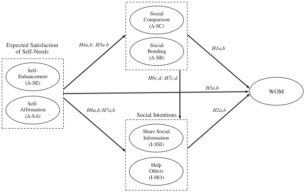

NOTE: figure/graphic rendered as an image from the PDF; its content is not machine-readable text. Caption (if any) follows as the next block.

**text found inside the figure**

*H6a,b;H7a,b*

*H3a,b*

Social Intentions

*H6c,d; H7c,d*

*H4a,b; H5a b*

*H2a,b*

*H1a,b*

WOM

Expected Satisfaction

of Self-Needs

Social Comparison

(Δ-SC)

Social Bonding

(Δ-SB)

Self- Enhancement

(Δ-SE)

Self- Affirmation

(Δ-SA)

Share Social

Information

(I-SSI)

Help Others (I-HO)

Social-Motives Outcome

Fig. 1 Research model. (The hypotheses for WOM valence are not depicted: H8, H9, and H10)

J. of the Acad. Mark. Sci. (2013) 41:531–546 533

Page 4

An action-oriented component of the model is intentions. Grosz and Sidner (1986) suggest the structure of every discourse includes intention. According to Bratman (1999), intention is conscious planning; people reason and intend to do something. We define the intention to share social information (I-SSI) as the degree to which a person intends to convey information about social norms and values by sharing information about brands; and the intention to help others (I-HO) as the degree to which a person intends to assist others by sharing information about brands.

We develop two sets of hypotheses in the following section. The first set examines the underlying causal sequence among model constructs depicted in Fig. 1. The second set focuses on the role of WOM valence and how the underlying process in the research model varies between positive and negative WOM.

Hypotheses for direct relationships

The initial set of research hypotheses is developed by examining first the impact of social motives on WOM and then the impact of self-needs on all variables in the model. We focus on two social-needs: social comparison and social bonding. Social comparison is the internal drive to compare a person’s abilities and opinions to those of others (Festinger

1954). This need is strong and emerges as people communicate with or think about other people. For instance, even when there is objective aggregate data available about performance of others, people are influenced more by individuals in close proximity than by the readily available objective information (Buckingham and Alicke 2002). People compare themselves with advertised images, although there is no real social presence (Gulas and McKeage 2000; Martin and Kennedy 1993; Pompper et al. 2007; Richins 1991). People may provide inaccurate brand information to others due to considerations of social comparison that can put them in an unfavorable position (Argo et al. 2006). In general, the mere presence of others, or just thinking about other people, triggers social comparison. Therefore, the intention to share WOM can be perceived as an opportunity to satisfy the need for social comparison.

The need to belong is a fundamental need; it states that people need to form and maintain bonds with others (Baumeister and Leary 1995). This need to bond also is echoed in research on gossip. The original concept of gossip to “speak ill of one’s fellows” (Dunbar 2004, p. 100) was substituted with the view that gossip serves a social purpose and is a form of communication that bonds people together (Baumeister et al. 2004). This general view of gossip asserts that “without gossip, there would be no society” (Dunbar

Table 1 Summary of variables in the study and their theoretical domains

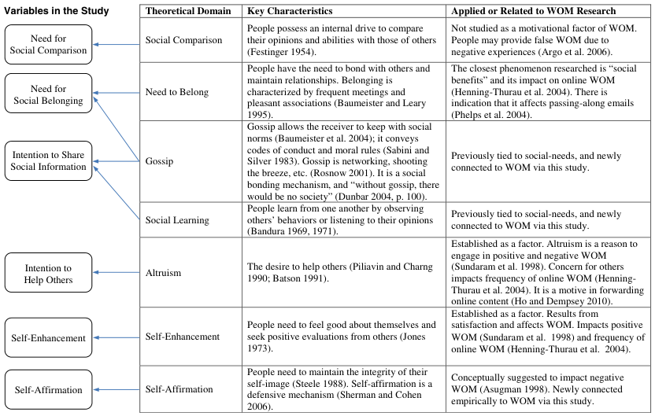

NOTE: complex table shown as an image of the PDF; the text below is a rough machine extraction and may be mis-aligned.

**extracted text (unreliable layout)**

534 J. of the Acad. Mark. Sci. (2013) 41:531–546

Page 5

2004, p. 100). The domain of gossip is particularly relevant in viewing WOM as a social process because it demonstrates how informal communication serves social-needs.

We reason that the urge to satisfy social-needs (i.e., social comparison and social bonding) encourages WOM. Therefore, we advance the following hypotheses:

H1: The needs for (a) social comparison and (b) social bonding positively affect WOM.

The impact of social intentions on WOM is represented by the intention to share social information and the intention to help others. We adopt the view of social information as moral stories about life and society in accordance with the social learning theory and gossip. When people chat and gossip, they convey codes of conduct and moral rules (Sabini and Silver 1983). According to the social learning theory, people learn from one another by observing others’ behaviors or listening to their opinions (Bandura 1969, 1971). A person identifies thoughts, feelings, or actions after observing another person who serves as a model, and the learned standards of performance can become the basis of self-evaluation (Gibson 2004). Therefore, WOM can be a tool for conveying moral stories and norms about society. Another motive behind WOM may be the intention to help others, or altruism, which already has been established as a factor in WOM (Hennig-Thurau et al. 2004; Ho and Dempsey 2010; Sundaram et al. 1998). WOM may be customized specifically to help the receiver. Therefore, a person may share WOM with the intention to better the society or to help others.

H2: The intentions to (a) share social information and (b) help others positively affect WOM.

The primary underlying motivational force in our model is represented by self-needs, the needs for selfenhancement and self-affirmation. Self-enhancement theory states that people need to feel good about themselves and seek positive evaluations from others: “they want to increase, confirm, and maintain personal satisfaction, worth, and effectiveness” (Jones 1973, p. 186). Selfaffirmation theory states that people need to maintain the integrity of their self-image (Steele 1988), which also can be used as a self-defense mechanism (Sherman and Cohen 2006). We include these two self-needs as ultimate motives because they are connected to ego, and people have strong drives to enhance and protect their egos (Alicke and Sedikides 2009). Although selfenhancement has been empirically examined in WOM studies (Hennig-Thurau et al. 2004; Sundaram et al. 1998), self-affirmation has been connected to WOM only conceptually (Asugman 1998). Self-affirmation may serve as a protective mechanism when the self is threatened (Fein and Spencer 1997; Koole et al. 1999; Steele and

Liu 1983), which can be the case after a negative experience with a brand. Therefore, we propose the following:

H3: The needs for (a) self-enhancement and (b) selfaffirmation positively affect WOM.

To define the relationship between social- and selfmotives, we distinguish between causal sequences in intentional and retrospective behavioral models. For example, if a person is hungry, which is a physiological need, he plans to eat expecting to satisfy his hunger. After the person has eaten, his hunger is satiated as a consequence of that behavior. Therefore, the causal sequence in an intentional model will be from hunger (i.e., need) to intention to eat, and the causal sequence in a retrospective behavioral model will be from the act of eating (i.e., behavior) to satiated hunger (i.e., satisfied need).

The above illustration provides the logical reasoning in our model, which proposes that self-motives activate socialmotives. The literature suggests that the self is, to a large extent, formed through interactions with others (Spencer et al. 2001). Many social-needs lack meaning without personal needs, as noted in research on social norms constructed to satisfy personal needs (Ostrom 2000). Therefore, social behavior can satisfy self-needs. From an intentional perspective, however, to satisfy their self-needs, people first intend to engage in social interactions. The social motives depicted in Fig. 1 should be viewed as an actualization of the intention for social interaction. The primal nature of the self suggests that the benefits of socializing would have no meaning without it, which means that the evaluation of selfrelated benefits should precede the intention for social interaction in an expectations-based model.

We reason that a person first evaluates the expected selfbenefits of sharing his brand experience, but to accrue them, he has to engage in a social interaction. The intended social interaction gives rise to various social considerations such as social-needs and intentions, which we combine as social motives. Together, the self and social motives result in an intention for a concrete behavior like WOM. After WOM is shared, it would satisfy social-needs, which in turn would satisfy self-needs.

Based on the above discussion, we argue that social-needs are activated by self-needs. For example, if I share my opinion about a brand, then I may be perceived as a good person (i.e., self-enhancement) and will express what I stand for (i.e., selfaffirmation); consequently, I should engage in a social process, which gives rise to the expected satisfactions of socialneeds typically associated with social interaction. Therefore, we advance the following hypotheses:

H4: The need for social comparison is positively affected by the needs for (a) self-enhancement and (b) self-affirmation.

J. of the Acad. Mark. Sci. (2013) 41:531–546 535

Page 6

H5: The need for social bonding is positively affected by the needs for (a) self-enhancement and (b) selfaffirmation.

Because social-motives are activated by self-needs, social intentions in the model also should result from self-needs. Furthermore, social intentions are explicit motives for a behavior that will satisfy both social- and self-needs. Social intentions in the model are part of the exchange process; helping others and providing social information have underlying reasons. Although it is possible to have purely altruistic behavior (Piliavin and Charng 1990), helping others often is considered as being motivated by self and egoistic objectives (Batson 1991). The “reward” in this case is the satisfaction of self- and social-needs. Similarly, sharing social information can be viewed as bettering the society, which also is a form of altruistic behavior. This line of reasoning is supported by Boulding et al. (1993) and Oliver (1980), who find that intentions are affected by expectations. Hence, the following hypotheses are tested:

H6: The intention to share social information is positively affected by (a) the need for self-enhancement, (b) the need for self-affirmation, (c) the need for social comparison, and (d) the need for social bonding. H7: The intention to help others is positively affected by (a) the need for self-enhancement, (b) the need for self-affirmation, (c) the need for social comparison, and (d) the need for social bonding.

Hypotheses for WOM valence: positive WOM versus negative WOM

We expect that cognitive mechanisms for positive and negative WOM differ. The attribution theory states that losses lead to different attributions than gains do, and people tend to praise themselves for successes and blame others for failures (Bradley 1978). Positive WOM can be associated with gains because people share opinions about the value received from a brand; negative WOM can be associated with loss, which can represent costs or lost value from a brand. Previous research confirms that people evaluate positive and negative experiences differently (Bryant 1989). The processes associated with positive events are referred to as capitalizing (Langston 1994), and the processes associated with negative events are avoiding and coping (Bryant 1989). In WOM, research has demonstrated that selfenhancement is a motive in positive WOM (Sundaram et al. 1998). On the other hand, self-affirmation has been shown to reduce cognitive dissonance (Steele and Liu 1983), lower rumination about negative experiences (Koole et al. 1999), and serve as a coping mechanism when the selfimage is threatened (Spencer et al. 2001), often by

derogating others (Fein and Spencer 1997). Overall, the manifestation of self-affirmation can be associated with negative WOM. Based on the above reasoning, we advance the following hypotheses:

H8a: Self-enhancement has a stronger total effect on positive WOM than it has on negative WOM. H8b: Self-affirmation has a stronger total effect on negative WOM than it has on positive WOM.

Responses to negative events generally involve avoiding and coping (Bryant 1989), which often require people to seek social support (Thoits 1986). In processing negative events, a person attempts to change the negative situation or its meaning (Thoits 1986). Negative WOM can be viewed as seeking social support by allowing the transmitter to represent the reality in a way that defends the self and ego. By sharing negative information about a brand, a person constructs meaning justifying himself. This process can be viewed as achieving cognitive clarity, which is essential for managing stress (Kirkpatrick and Shaver 1988). Specifically, the process of coping may be projected through the intention to help others, thus trying to protect them. The process of avoidance may be projected through sharing social information about social norms and values, thus justifying why a brand should be avoided. In addition, negative events are perceived as more urgent than positive events and as requiring action (Taylor 1991), which suggests that negative events are more likely to result in specific intentions. Cumulatively, the literature suggests that:

H10: The (a) intention to share social information and the (b) intention to help others will have a stronger effect on negative WOM than on positive WOM.

536 J. of the Acad. Mark. Sci. (2013) 41:531–546

Page 7

Method

Sample and data collection

We tested our model separately for positive and negative WOM using two scenarios. In the first scenario, respondents were asked to think about a brand toward which they had positive feelings; in the second scenario, respondents were asked to think about a brand toward which they had negative feelings. The brands in both scenarios had to be such that respondents would naturally mention them to family or friends in a casual conversation. The scenarios did not impose restrictions and allowed respondents to consider any brand, even brands with which they may not have had direct experience. Respondents wrote the brand they had in mind on the survey and were asked to answer all questions with that specific brand in mind. For the indicated brands, we measured the likelihood to share positive WOM in the first scenario and the likelihood to share negative WOM in the second scenario. This was the only difference between the two scenarios; all remaining measures were the same.

We collected data from students in a Midwestern U.S. university, who participated in exchange for credit. All contacted students agreed to participate. The data were collected online by assigning respondents randomly to one of the two scenarios. The initial number of responses was 494. Because online data collection may pose challenges (Granello and Wheaton 2004), we used several techniques to extract only usable data. First, we discarded all respondents who completed the survey in less than five minutes. Second, to make sure respondents had read the questions, we embedded a verifying question stating, “Please select ‘Agree’ to show that you are reading the question.” All respondents who did not select “Agree” were discarded. Third, we discarded data from all respondents who did not complete the survey. Finally, we examined the data visually and discarded all respondents who had unnaturally long sequences of repetitive answers for all questions. As a result, data from 394 usable responses remained; positive WOM with 202 responses and negative WOM with 192 responses. About 43% of the final respondents were females, and about 57% were males. A brief description of the selected brands for positive and negative WOM is provided in Table 2; most of the WOM activities involve retailers, followed by fashion brands, electronics, and automotive.

Measures

Some measures were based on the existing literature, and others were developed for the present study. The general format of the scales was as follows: both positive and negative WOM were measured as likelihood, with responses ranging from “1-Very Unlikely” to “7-Very Likely,” and the

rest of the measures were in Likert scale format, with responses ranging from “1-Strongly Disagree” to “7-Strongly Agree.” The expected satisfaction of the need for selfenhancement measure was based on Seokhwa et al. (2007), and the expected satisfaction of the need for self-affirmation measure was based on Napper et al. (2009). The expected satisfaction of the need for social comparison measure was developed for the present study and based on insight from social comparison theory (Festinger 1954); the expected satisfaction of the need for social bonding was developed for the present study and based on Baumeister and Leary (1995). The intention to share social information measure was developed for the present study and based on the gossip and social learning literature (Bandura 1969; Baumeister et al. 2004). Finally, the intention for helping behavior measure was developed based on altruistic measures (Price et al. 1995), but customized to WOM. The development of the new measures was consistent with scale development procedures (Anderson and Gerbing 1988; Hinkin 1995). Two independent judges were used for this purpose. The judges generated an initial pool of items, and after debate and discussion, they kept only items where consensus was achieved. Exploratory and confirmatory factor analysis followed until the final structure of the measures emerged. The following section provides more details.

Results

Measurement results

We expected that social desirability could be a source of method variance (Podsakoff et al. 2003). We included the

Table 2 Brand categories mentioned

[output not shown]

NOTE: table converted from PDF layout to HTML text; cell boundaries are reconstructed. See PDF if exact alignment matters.

J. of the Acad. Mark. Sci. (2013) 41:531–546 537

Page 8

social desirability scales (i.e., egoistic and moralistic response tendencies) developed by Steenkamp et al. (2010) in the survey. However, an initial factor analysis revealed that the two social tendencies scales did not load as expected, so we did not use the scales as initially intended, but did include their items in the subsequent common method variance analysis.

Next, we performed principal component analysis with all items forced to load on a single factor in order to evaluate the variance of a potential common method factor. The extracted variance in the samples for positive and negative WOM was fairly small, 26% and 18% respectively, which indicated that the amount of common method variance could be small (Podsakoff et al. 2003). After this, we assessed the impact of a common method factor on all scale items. In a model with all measures, including the social tendencies scale items, we modeled a common method factor. Results revealed that the common method factor had a significant, but very small, impact on all items. The effects in the positive and negative WOM samples were 0.04 and 0.18, respectively. The model fit was poor, and all fit statistics were unacceptable. Further, following Spector (2006), we examined the observed correlations among all items in the two samples. About one fourth of all correlations were not significant, indicating that common method variance did not inflate relationships. Collectively, the results indicate that there is common method variance, but its impact is negligible; therefore, we did not consider it in the rest of the analysis.

underlying factors and none of the items showed large cross-loadings.

We note that data from the indicators for positive and negative WOM depart from normal distribution. This was expected because in the two scenarios, we asked the respondents to select a brand about which they held positive (or negative) views; naturally, the respondents selected brands about which they had relatively strong feelings. All remaining indicators follow normal distribution. The Robust Maximum-Likelihood method was used for all analyses including the WOM measures, which is recommended when the variables deviate from normality (Jöreskog et al. 2000).

Measurement invariance

The results from confirmatory factor analysis established configural invariance (Vandenberg and Lance 2000). The next step was the examination of the metric invariance, or whether the factor loadings of the items were equal across the samples. The analysis for establishing metric invariance did not include the positive and negative WOM measures because they were measured differently. First, we tested the measurement model by simultaneously analyzing the sample covariance matrices of positive WOM and negative WOM groups, with no restrictions on any of the model parameters. Then, we repeated the analysis with equality constraints imposed on only one factor loading at a time. Only three items were found to differ significantly across the two groups: one from the need for self-affirmation, one from the need for social comparison, and one from the intention for helping behavior scale. These results indicate that we achieved partial metric invariance with a minimum number of non-equivalent items, which is sufficient because our purpose is to compare the relationships among various constructs in a model (Hair et al. 2005; Steenkamp and Baumgartner 1998; Vandenberg and Lance 2000). Descriptive statistics of the measures are presented in Table 3, and items with the measurement properties of the scales are presented in Table 4.

538 J. of the Acad. Mark. Sci. (2013) 41:531–546

Page 9

Tests of research model and hypotheses for underlying causal process

Because the main dependent variable, WOM, was measured differently in the two samples, it was not possible to perform a two-group simultaneous analysis. We already established partial metric invariance with only three items differing across the groups, and we used the estimated factor loadings from the two-group CFA analysis to fix the factor loadings in the hypothesized model in the two samples. By doing this, we could make meaningful comparisons of path coefficients.

Section I in Table 5 summarizes the results of the direct effects on WOM. The effect of social comparison on WOM (H1a) is supported for both positive and negative WOM. The effect of social bonding (H1b) and the effect of selfenhancement (H3a) are supported only for positive WOM. In contrast, the effects of the intentions to share social information (H2a) and to help others (H2b) are supported

Table 3 Descriptive statistics

| Mean | Std . . | WOM | ΔSE - | ΔSA - | ΔSC - | ΔSB - | ISSI - | IHO - |
| --- | --- | --- | --- | --- | --- | --- | --- | --- |
| PositiveWOM(n0202) |  |  |  |  |  |  |  |  |
| WOM 629 . | 079 . | 100a . |  |  |  |  |  |  |
| ΔSE 513 - . | 107 . | 49a . | 100a . |  |  |  |  |  |
| ΔSA 463 - . | 123 . | 32a . | 65a . | 100a . |  |  |  |  |
| ΔSC 577 - . | 083 . | 57a . | 57a . | 41a . | 100a . |  |  |  |
| ΔSB 477 - . | 108 . | 47a . | 62a . | 73a . | 58a . | 100a . |  |  |
| ISSI 394 - . | 137 . | 20a . | 42a . | 53a . | 22a . | 58a . | 100a . |  |
| IHO 552 - . | 090 . | 37a . | 52a . | 31a . | 62aa . | 53a . | 32a . | 100a . |
| NegativeWOM(n0192) |  |  |  |  |  |  |  |  |
| WOM 532 . | 119 . | 100a . |  |  |  |  |  |  |
| ΔSE 407 - . | 114 . | 10 . | 100a . |  |  |  |  |  |
| ΔSA 441 - . | 135 . | 26a . | 46a . | 100a . |  |  |  |  |
| ΔSC 529 - . | 107 . | 44a . | 27a . | 31aa . | 100a . |  |  |  |
| ΔSB 430 - . | 115 . | 15 . | 32a . | 51a . | 020a . | 100a . |  |  |
| ISSI 419 - . | 135 . | 28a . | 28a . | 60a . | 020a . | 56a . | 100a . |  |
| IHO 497 - . | 122 . | 39a . | 27a . | 25a . | 046a . | 22a . | 23a . | 100a . |

NOTE: table converted from PDF layout to HTML text; cell boundaries are reconstructed. See PDF if exact alignment matters.

a Significant at 95% confidence level and above. The means and standard deviations are based on averaged scores; the correlations are based on latent scores

Δ expected satisfaction of a need, I intention, SE self-enhancement, SA self-affirmation, SC social comparison, SB social bonding, HO help others, SSI share social information

J. of the Acad. Mark. Sci. (2013) 41:531–546 539

Page 10

Table 4 Confirmatory factor analysis and measurement properties of the scales

|  | PositiveWOM | NegativeWOM |
| --- | --- | --- |
| PositiveWOM |  |  |
| How likely would you be to do any of the following … | 86\| 74\| 04 34a . . . –. |  |
| 1 Say positive things about this brand . | 78b . |  |
| 2 Recommend this brand to others . | 84 . |  |
| 3 . Recommend this brand to someone else who seeks my advice | 95 . |  |
| NegativeWOM |  |  |
| How likely would you be to do any of the following … |  | 82\| 65\| 01 19 . . . –. |
| 1 . Warn my friends and relatives not to buy this brand |  | 76 . |
| 2 . Complain to my friends and relatives about this brand |  | 82 . |
| 3 Say negative things about this brand to other people . |  | 83 . |
| Expected Satisfaction of the Need for Self -Enhancement (Δ -SE) |  |  |
| If I share my opinion about this brand in a conversation… | 79\| 61\| 10 42 . . . –. | 84\| 65\| 01 19 . . . –. |
| 1 . It will create the impression that I am a “good” person | 83 . | 83 . |
| 2 . I will receive positive feedback from others about my gesture | 78 . | 83 . |
| 3 . I will create a positive impression on others | 73 . | 76 . |
| Expected Satisfaction of the Need for Self -Affirmation (Δ -SA) |  |  |
| If I share my opinion about this brand in a conversation… | 92\| 70\| 10 53 . . . –. | 93\| 73\| 05 36 . . . –. |
| 1 . It will reveal who I am | 85 . | 86 . |
| 2 It will reveal what I stand for . | 89 . | 86 . |
| 3 . It will make the other person aware of what I value about myself | 80 . | 92 . |
| 4 . It will make the other person understand what is important to me | 81 . | 85 . |
| 5 . It will make me think about positive aspects of myself | 82 . | 78 . |
| Expected Satisfaction of the Need for Social Comparison (Δ -SC) |  |  |
| If I share my opinion about this brand , it will allow me to compare… | 81\| 59\|05 34 . . . –. | 83\| 65\| 04 21 . . . –. |
| 1 My opinion about the brand to others’ opinions . | 74 . | 83 . |
| 2 My feelings of the brand to the feelings of other people . | 75 . | 80 . |
| 3 My experience with this brand to the experiences of others . | 81 . | 78 . |
| Expected Satisfaction of the Need for Social Bonding (Δ -SB) |  |  |
| If I share my opinion about this brand in a conversation… | 81\| 59\| 22 53 . . . –. | 84\| 62\| 03 31 . . . –. |
| 1 . It will provide a topic for further discussion with this person | 74 . | 75 . |
| 2 . It will benefit the relationship with this person | 78 . | 83 . |
| 3 . It will help me learn more about the person I'm talking with | 79 . | 81 . |
| Intention to Share Social Information (I-SSI) |  |  |
| When sharing my opinion about this brand with another person, I want them … | 94\| 80\| 04 34 . . . –. | 93\| 77\| 03 36 . . . –. |
| 1 . To learn the standards of other people acceptable in our society | 87 . | 78 . |
| 2 . To understand the values of our society | 93 . | 92 . |
| 3 . To understand how our society tells right from wrong | 92 . | 93 . |
| 4 . To learn a moral story from our lives | 85 . | 87 . |
| Intention to Help Others (I-HO) |  |  |
| When sharing my opinion about this brand with another person, I want … | 77\| 59\| 12 38 . . . –. | 86\| 69\| 03 21 . . . –. |
| 1 . To help them be a better customer | 73 . | 71 . |
| 2 To help them get the information they want/need . | 80 . | 95 . |
| 3 . To help them form an opinion about the brand or related issues | 79 . | 82 . |

NOTE: table converted from PDF layout to HTML text; cell boundaries are reconstructed. See PDF if exact alignment matters.

a For each scale, the three numbers above the loadings correspond to α | AVE | Φ2

, <sup>where</sup><sup>α</sup><sup>is Cronbach</sup><sup>’</sup><sup>s alpha, AVE is average variance extracted,</sup> and Φ<sup>2</sup> is shared variance

b All loadings are significant at 99% confidence level (t-value>2.57)

540 J. of the Acad. Mark. Sci. (2013) 41:531–546

Page 11

only for negative WOM. There is no direct effect of selfaffirmation on WOM, lending no support for H3b.

Section II in Table 5 summarizes the effects of self-needs on social-needs. The effect of self-enhancement on social comparison (H4a) and the effect of self-affirmation on social bonding (H5b) are supported for both positive and negative WOM. Self-affirmation affects social comparison (H4b) only for negative WOM, and self-enhancement affects social bonding (H5a) only for positive WOM.

Section III in Table 5 summarizes the effects of all needs on social intentions. The effects of self-affirmation and social bonding on the intention to share social information (H6b and H6d) and the effect of social comparison on the intention to help others (H7c) are supported for both positive and negative WOM. The effects of selfenhancement and social bonding on the intention to help others (H7a and H7d) are supported only for positive WOM. The results reveal no support for the effects of self-enhancement and social comparison on the intention to share social information (H6a and H6c). Contrary to our prediction, self-affirmation showed a significant

negative impact on the intention to help others, thus lending no support for H7b.

Tests of hypotheses for WOM valence

Because the dependent variables in the two groups were different (i.e., positive WOM and negative WOM), a straightforward multigroup analysis was not possible. Therefore, we tested the equality of the path coefficients using the approach suggested by Brame et al. (1998) and Paternoster et al. (1998), which allows testing the equivalence of linear regression coefficients from two independent samples, as is the case in the study. A direct comparison of the path coefficients was possible because the measurement models of the two samples were fixed to be equivalent. The resulting t-values from the test for differences between path coefficients are provided in Table 5.

The total effects of self-enhancement and self-affirmation on WOM are in contrast, as expected. Although the total effect of self-enhancement is significant only for positive WOM, the total effect of self-affirmation is significant only

Table 5 Test of structural model and research hypotheses

|  |  | Hypotheses supportedfor (P/N) | Structuralmodel parameter | PositiveWOM β t-value | NegativeWOM β t-value |  | R2 (P/N) | Pathdifference t-value |
| --- | --- | --- | --- | --- | --- | --- | --- | --- |
| SectionI | H1a | P/N | Δ -SC→WOM | 42 (390) . . | 32 . | (344) . | 38/ 28 . . | 65 . |
| EffectsonWOM | H1b | P | Δ -SB→WOM | 30 (204) . . | −.07 | (−.67) |  | 196 . |
|  | H2a | N | I -SSI→WOM | −.05 (−.60) | 19 . | (187) . |  | −1 .81 |
|  | H2b | N | I -HO→WOM | −.09 (−.87) | 23 . | (258) . |  | −2 .13 |
|  | H3a | P | Δ -SE→WOM | 25 (210) . . | −.12 | (−1 .30) |  | 230 . |
|  | H3b | Nosupport | Δ -SA→WOM | −.17 (−1 .41) | 07 . | (65) . |  | 146 . |
| SectionII | H4a | P/N | Δ -SE→Δ -SC | 54 (522) . . | 15 . | (167) . | 34/ 12 . . | 271 . |
| Effects on social -needs | H4b | N | Δ -SA→Δ -SC | 07 (68) . . | 24 . | (268) . |  | −1 .33 |
|  | H5a | P | Δ -SE→Δ -SB | 28 (315) . . | 10 . | (121) . | 58/ 27 . . | 142 . |
|  | H5b | P/N | Δ -SA→Δ -SB | 55 (640) . . | 46 . | (547) . |  | 77 . |
| SectionIII | H6a | Nosupport | Δ -SE→I -SSI | 08 (70) . . | −.03 | (−.40) | 39/ 45 . . | 77 . |
| Effectsonsocialintentions | H6b | P/N | Δ -SA→I -SSI | 19 (176) . . | 44 . | (543) . |  | −.84 |
|  | H6c | Nosupport | Δ -SC→I -SSI | −.14 (−1 .56) | 01 . | (07) . |  | −1 .29 |
|  | H6d | P/N | Δ -SB→I -SSI | 47 (393) . . | 34 . | (443) . |  | 86 . |
|  | H7a | P | Δ -SE→I -HO | 24 (198) . . | 12 . | (133) . | 46/ 24 . . | 81 . |
|  | H7b | Nosupport | Δ -SA→I -HO | −.28 (−2 .31) | 03 . | (31) . |  | −2 .09 |
|  | H7c | P/N | Δ -SC→I -HO | 40 (424) . . | 40 . | (489) . |  | 00 . |
|  | H7d | P | Δ -SB→I -HO | 38 (299) . . | 09 . | (103) . |  | 217 . |
| Totaleffects | H8a | Supported | Δ -SE→WOM | 50 (481) . . | −.05 | (00) . |  | 370 . |
|  | H8b |  | Δ -SA→WOM | −.03 (−.29) | 25 . | (290) . |  | 197 . |
| Indirecteffects |  |  | Δ -SE→WOM | 25 (320) . . | 09 . | (180) . |  |  |
|  |  |  | Δ -SA→WOM | 17 (187) . . | 20 . | (260) . |  |  |

NOTE: table converted from PDF layout to HTML text; cell boundaries are reconstructed. See PDF if exact alignment matters.

Δ expected satisfaction of a need, I intention, SE self-enhancement, SA self-affirmation, SC social comparison, SB social bonding, HO help others, SSI share social information. P/N corresponds to Positive/Negative WOM. T-values are in parentheses. Based on one-tail t-test: t-values>1.3, p<.10; t-values>1.65, p<.05; t-values>2.33, p<.01 (Singh 2000). Significant path coefficients at p<.05 are in bold

J. of the Acad. Mark. Sci. (2013) 41:531–546 541

Page 12

for negative WOM. The significant differences of the total effects, as indicated by the t-values, lend support for H8a and H8b. The results also reveal that half of the total effect of self-enhancement is delivered directly, and the total effect of self-affirmation is delivered mostly indirectly. Similarly, the effect of social bonding on WOM is significantly higher for positive than for negative WOM (H9b). However, despite the expected direction of the difference, the effects of social comparison are not significantly different for positive and negative WOM, thus lending no support for H9a. Hypotheses 10a and 10b are supported in that the effects of the intention to share social information and helping others are significantly higher for negative than for positive WOM.

Discussion

Overall, results support the viability of the proposed model that WOM is driven by self- and social-motives. Of the 24 specific hypotheses tested, 19 were supported for positive WOM, negative WOM or both. One important finding is that positive and negative WOM have different routes of activation. These results are consistent with previous research. For example, Sundaram et al. (1998) also found differences based on WOM valence employing critical incident techniques. We replicate the effects of altruism (Ho and Dempsey 2010; Sundaram et al. 1998; Hennig-Thurau et al. 2004) and self-enhancement (Hennig-Thurau et al. 2004; Sundaram et al. 1998) on WOM.

The contribution of the present study is in two main areas. First, as a social interaction process, positive WOM is driven mainly by the need to enhance the self-image, and negative WOM is motivated by the need to affirm identity. From a self-enhancement or a self-affirmation perspective, WOM is a way of saying “Perceive me well” or “This is me!” The finding that positive WOM is affected mainly by self-enhancement indicates that the transmitter ultimately seeks to capitalize by boosting his self-image, and that negative WOM is affected mainly by self-affirmation clearly indicates that the ultimate motive is the protection of the ego. Our results are nomologically aligned with prior findings in the literature, as using self-affirmation as a defense mechanism has been established (Sherman and Cohen 2006; Steele and Liu 1983), and apparently negative WOM can be used to rebuild a damaged self-image.

Second, social motives (i.e., social-needs and social intentions) affect WOM significantly and play an important role in the transmission of differential effects of the selfmotives. Positive WOM is influenced by the satisfaction of social-needs, and negative WOM is influenced more by social intentions in addition to social comparison. This outlines an important function of social motives. When transmitting positive information, people expect only social gains

(i.e., social comparison and social bonding). In contrast, people approach the transmission of negative information mostly with specific social intentions (i.e., to help others and to share social information). Social comparison also affects negative WOM, but its effect is smaller compared to the cumulative effect of social intentions. Another important insight is that social motives play a partial mediating role of the effect of self-enhancement, but they act as a full mediator of the effect of self-affirmation. Specifically, in positive WOM, self-enhancement affects WOM directly and indirectly through social bonding and social comparison. In negative WOM, the effects of self-affirmation are transmitted through the intentions to share social information and intentions to help others, and through social comparison.

In summary, the benefits accrued through positive WOM are the satisfaction of the needs for self-enhancement, for social comparison, and to bond with others. The benefits accrued through negative WOM are the satisfaction of the needs for self-affirmation and social comparison, but this gain is delivered through the intentions to share social information and to help others.

Finally, to provide partial evidence for the external validity of the findings, we decided to explore if students are more or less likely to engage in positive and negative WOM than non-students. Previous research suggests that using student samples does not lead to significant differences in studies on WOM (de Matos and Rossi 2008). In a small complementary study, we measured the propensity to engage in positive and negative WOM, the need for social bonding, and the need for social comparison from 56 students and 22 non-student adults. We used the same measures as in the main study, but not tied to a specific brand. A multivariate analysis of variance (MANOVA) result indicated non-significant differences between students and non-students for all four dependent variables (Wilks’ Lambda0.973, p0.733): likelihood to engage in positive WOM (x student<sup>0</sup><sup>5.74,</sup> <sup>x</sup> non-student<sup>0</sup><sup>5.70),</sup> <sup>likelihood</sup> <sup>to</sup> engage in negative WOM (x student05.31, x non-student<sup>0</sup> 5.20), social comparison (x student05.33, x non-student05.51), and social bonding ( x student<sup>0</sup><sup>6.11,</sup> <sup>x</sup> non-student<sup>0</sup><sup>5.92).</sup> Although these results do not provide direct evidence about the equality of hypothesized linkages in the model, they do point that the two groups are similar with respect to WOM behavior, adding strength to the current study.

Managerial implications

Managers should realize WOM is a form of social interaction. Although the exchanged content is related to brands, the WOM act serves various self- and social-needs. For example, some people purchase new technology items partly so they can talk (brag) to their friends and colleagues

542 J. of the Acad. Mark. Sci. (2013) 41:531–546

Page 13

about their purchases. This type of behavior indicates communication strategies could be developed that encourage purchases based on ability to engage in WOM.

Important practical implications relevant to brand strategies can be derived from the results of the study: how to encourage positive WOM, and how to encourage or discourage negative WOM. Encouraging positive WOM is, perhaps, the most desirable outcome. Our results indicate managers could leverage factors affecting positive WOM including social comparison, need to bond with others, and self-enhancement. A campaign that targets the sharing of positive WOM should sound like: “Tell others what a great choice you made, make friends, and see what they think.” For example, employee “water cooler” talk often includes conversations about recent television shows. Individuals who missed watching these shows lack the ability to participate in these conversations, and some individuals will watch shows largely to enable themselves to be “in on the conversation.” Producers of these events wish to attract viewers and may benefit by using strategies that emphasize the risk of being a social outcast, not knowing or understanding the current trends by not watching the shows.

To demotivate customers from sharing negative WOM, social comparison, helping behavior, social information, and self-affirmation should be discouraged. A promotional theme targeting such behavior should sound like: “People are different and everyone makes their own choices. Your needs are different from theirs, and your help may not be in their best interest.” For example, Merrill Lynch investing has used promotions with a bull that encourages people to think about standing apart from the pack when selecting an investment advisor, which could discourage negative WOM.

Conversely, if a company wants to motivate customers to share their negative experiences with a competing brand, they should encourage the four drivers of negative WOM. Such a message should sound like: “Help others be better customers; tell them what is considered right and wrong in our society. Share your values and learn what theirs are.” An example of such a campaign is reflected in advertising for Pace Picante Sauces where rugged men sit by a campfire and chide a fellow camper for using sauce made in New York City.

Specifically, our findings are relevant in the wake of the explosion of social and mobile media. Apps can be designed in which the message to the consumer would be less about the brand and more about the gain associated with sharing an opinion. Our results suggest that the value of brand name placement may increase if the brand name is accompanied by a word or image that encourages a consumer to socialize with others, so the likelihood of a social conversation increases, and the brand becomes part of the conversation. For example, social media strategies that encourage sharing

positive and suppressing negative experiences with a brand should provide a platform that: (1) builds communal elements rewarding social connections and likes by others; (2) helps express uniqueness and self-identity outside the brand so that self-affirmation can be achieved in ways other than negative WOM; (3) differentiates the brand so that social norms and helping others become less applicable; and (4) provides a rich helping mechanism in case it is needed, taking away that function from negative WOM. The importance of such a strategy is that it can be implemented even before a purchase is made, which means that contextual social factors can prepare customers for a particular WOM behavior even before experiencing the brand.

From a broader perspective, the recommendations above resemble the strategies of two popular brands: Harley Davidson and Apple. Overall, these brands offer products with high quality and appeal whose ownership leads to perception of self-enhancement, which can lead to desire for social bonding. On the other hand, the brands are different from the mainstream competitors, and the promotion of individuality is so high that the widely accepted social norms and helping behavior are less applicable, which may naturally suppress the transferability of negative experiences. Indirect support for the last assumption is provided by Folkes and Patrick (2003), who found that in services, where there are diverse outcomes depending on the consumer, negative experiences are more difficult to transfer than positive experiences are. From a social perspective, the success of Harley Davidson and Apple may be due partially to a positioning that encourages positive WOM and dampens negative WOM.

Generalizing the example above even further, the results indicate that maximizing positive WOM and minimizing negative WOM can be achieved in a differentiated community with above average customer experiences. In such a community, all social ingredients for optimal WOM are present. The above average experiences (e.g., quality, service, brand image, etc.) will encourage self-enhancement. The communal element will facilitate social bonding. The differentiation and emphasis on individuality will lower the impact of social norms and make helping others less valid. A limiting factor of such a marketing strategy is that the community will have to remain fairly small; otherwise it will lose its differentiation.

Limitations and further research avenues

Although providing encouraging results, this study has limitations. First, an array of covariates exists that could be helpful to test: satisfaction, loyalty, quality, commitment, trust, and perceived value (de Matos and Rossi 2008); emotion, surprise, interest, and usefulness (Berger and Milkman 2012); and public visibility (Berger and Schwartz

J. of the Acad. Mark. Sci. (2013) 41:531–546 543

Page 14

2011). However, the model we tested is already complex, and including various types of covariates adds challenges in both statistical testing and conceptually thinking about causal directions and moderating or mediating effects. We view this omission as a tradeoff, probing more inclusively at the social aspects of WOM, and recognizing that areas are an important research avenue to continue. The study was meant mainly to provide an integrative picture of the nature of WOM as a social interaction process.

Second, we measured WOM in scenarios encouraging respondents to share brands they would naturally mention to others. Although this approach is realistic and captures the expected tendencies of respondents to share what they actually would do, it results in a sample consisting of a variety of brands across industries. Yet we do not control for brand or industry effects in our study. Examining the research model in different industries and on individual brand levels is warranted. It is logical to assume that some industries and brands will be highly prone to contextual factors we discuss in this paper, and other brands will be less prone.

Third, the results reveal strong contrasts based on WOM valence, as suggested by Sundaram et al. (1998). Our research confirms that the nature of positive and negative WOM takes different routes. Future research should focus on clarifying the unique motives behind positive and negative WOM as a social process, which may include additional variables. Further, the unexpected significant and opposite effect in H7b warrants an explanation. There are three plausible reasons for this finding. First, the negative sign actually may be representing the true nature of the relationship, which is difficult to justify on theoretical grounds. Second, the result may be due to the influence of variables not included in our research model. Third, negative suppression may be the underlying reason for the unexpected finding (Conger 1974; Maassen and Bakker 2001; Tzelgov and Henik 1991). The difference between the correlation and regression signs points to negative suppression. In a post hoc analysis we found that the removal of self-affirmation as a predictor of helping behavior lowered the regression coefficients of other variables, which also suggests negative suppression. However, the issue needs further research attention.

Finally, the study does not establish causal relationships because we use single-source data generated from a crosssectional survey. The hypothesized and tested relationships were grounded in the existing literature. A strong test of our model can be conducted via experimental studies where the effects of different promotional themes are compared. Our study is an important stepping stone for further research in this direction.

In conclusion, the study answers the call for more attention on social aspects of consumer behavior (Bagozzi 2000; Wright 2002). The proposed research model helps

understand the purpose of WOM by recognizing that WOM serves social- and self-needs. The results in our work provide a unifying picture, and can suggest rich out-of-thebox managerial strategies.

References

Alicke, M. D., & Sedikides, C. (2009). Self-enhancement and self-

protection: what they are and what they do. European Review of Social Psychology, 20, 1–48. Anderson, E. W. (1998). Customer satisfaction and word of mouth.

Journal of Service Research, 1, 5–17. Anderson, J. W., & Gerbing, J. C. (1988). An updated paradigm for

scale development incorporating unidimensionality and its assessment. Journal of Marketing Research, 25, 186–192. Argo, J. J., White, K., & Dahl, D. W. (2006). Social comparison theory

and deception in the interpersonal exchange of consumption information. Journal of Consumer Research, 33, 99–108. Asugman, G. (1998). An evaluation of negative word-of-mouth re-

search for new extensions. In B. G. Englis & A. Olofsson (Eds.), European advances in consumer research volume 3 (pp. 70–75). Provo: Association for Consumer Research. Bagozzi, R. P. (2000). On the concept of intentional social action in

consumer behavior. Journal of Consumer Research, 27, 388–396. Bagozzi, R. P., Baumgartner, H., & Yi, Y. (1992). State versus action

orientation and the theory of reasoned action: an application to coupon usage. Journal of Consumer Research, 18, 505–518. Bandura, A. (1969). Social-learning theory of identificatory processes.

In D. A. Goslin (Ed.), Handbook of socialization theory and research (pp. 213–262). Chicago: Rand McNally. Bandura, A. (1971). Social learning theory of aggression. In J. G.

Knutson (Ed.), Control of aggression: Implications from basic research (pp. 201–250). Chicago: Aldine-Atherton. Bargh, J. A., & Chartrand, T. L. (1999). The unbearable automaticity of

being. American Psychologist, 54, 462–479. Batson, D. C. (1991). The altruism question: Toward a social psycho-

logical answer. Hillsdale: Lawrence Erlbaum Associates. Baumeister, R. F., & Leary, M. R. (1995). The need to belong: desire

for interpersonal attachments as a fundamental human motivation. Psychological Bulletin, 117, 497–529. Baumeister, R. F., Leary, M. R., Zhang, L., & Vohs, K. D. (2004).

Gossip as cultural learning. Review of General Psychology, 8, 111–121. Berger, J. (2011). Arousal increases social transmission of information.

Psychological Science, 22, 891–893. Berger, J., & Milkman, K. L. (2012). What makes online content viral?

Journal of Marketing Research, 49, 192–205. Berger, J., & Schwartz, E. M. (2011). What drives immediate and

ongoing word of mouth? Journal of Marketing Research, 48, 869–880. Blair, I. V. (2002). The malleability of automatic stereotypes and

prejudice. Personality and Social Psychology Review, 6, 242–261. Blau, P. M. (1986). Exchange and power in social life. Piscataway:

Transaction Publishers. Boulding, W., Kalra, A., Staelin, R., & Zeithaml, V. A. (1993). A

dynamic process model of service quality: from expectations to behavioral intentions. Journal of Marketing Research, 30, 7–27. Bowman, D., & Narayandas, D. (2001). Managing customer-initiated

contacts with manufacturers: the impact on share of category requirements and word-of-mouth behavior. Journal of Marketing Research, 38, 281–297.

544 J. of the Acad. Mark. Sci. (2013) 41:531–546

Page 15

Bradley, G. W. (1978). Self-serving biases in the attribution process: a

reexamination of the fact or fiction question. Journal of Personality and Social Psychology, 36, 56–71. Brame, R., Paternoster, R., Mazerolle, P., & Piquero, A. (1998). Test-

ing for the equality of maximum-likelihood regression coefficients between two independent equations. Journal of Quantitative Criminology, 14, 245–261. Bratman, M. (1999). Intention, plans, and practical reason. Stanford:

Cambridge University Press. Brown, T. J., Barry, T. E., Dacin, P. A., & Gunst, R. F. (2005).

Spreading the word: investigating antecedents of consumers’ positive word-of-mouth intentions and behaviors in a retailing context. Journal of the Academy of Marketing Science, 33, 123–138. Bryant, F. B. (1989). A four-factor model of perceived control: avoid-

ing, coping, obtaining, and savoring. Journal of Personality, 57, 773–797. Buckingham, J. T., & Alicke, M. D. (2002). The influence of individ-

ual versus aggregate social comparison and the presence of others on self-evaluations. Journal of Personality and Social Psychology, 83, 1117–1130. Byrne, R. W., & Whiten, A. (1989). Machiavellian intelligence: Social

expertise and the evolution of intellect in monkeys, apes, and humans. New York: Oxford University Press. Cheung, M., Anitsal, M. M., & Anitsal, I. (2007). Revisiting word-of-

mouth communications: a cross-national exploration. Journal of Marketing Theory and Practice, 15, 235–249. Conger, A. J. (1974). A revised definition for suppressor variables: a

guide to their identification and interpretation. Educational and Psychological Measurement, 34, 35–46. de Matos, C. A., & Rossi, C. A. V. (2008). Word-of-mouth communi-

cations in marketing: a meta-analytic review of the antecedents and moderators. Journal of the Academy of Marketing Science, 36, 578–596. Deci, E., & Ryan, R. (2000). The ‘what’ and ‘why’ of goal pursuits:

human needs and the self-determination of behavior. Psychological Inquiry, 11, 227–268. Dichter, E. (1966). How word-of-mouth advertising works. Harvard

Business Review, 44, 147–160. Dunbar, R. I. M. (2004). Gossip in evolutionary perspective. Review of

General Psychology, 8, 100–110. Dunbar, R. I. M., Marriott, A., & Duncan, N. D. C. (1997). Human

conversational behavior. Human Nature, 8, 231–246. Emerson, R. M. (1976). Social exchange theory. Annual Review of

Sociology, 2, 335–362. Emler, N. (1992). The truth about gossip. Social Psychology Newslet-

ter, 27, 23–37. Emler, N. (1994). Gossip, reputation, and social adaptation. In R. F.

Goodman & A. Ben-Ze’ev (Eds.), Good gossip (pp. 117–138). Lawrence: University of Kansas Press. Engel, J. F., Blackwell, R. D., & Miniard, P. W. (1993). Consumer

behavior (8th ed.). Fort Worth: Dryden Press. Fein, S., & Spencer, S. J. (1997). Prejudice as self-image maintenance:

affirming the self through derogating others. Journal of Personality and Social Psychology, 73, 31–44. Festinger, L. (1954). A theory of social comparison processes. Human

Relations, 7, 117–140. Folkes, V. S., & Patrick, V. M. (2003). The positivity effect in percep-

tions of services: seen one, seen them all? Journal of Consumer Research, 30, 125–137. Fornell, C., & Larcker, D. F. (1981). Evaluating structural equation

models with unobservable variables and measurement error. Journal of Marketing Research, 18, 39–50. Gibson, S. K. (2004). Social learning (cognitive) theory and implica-

tions for human resource development. Advances in Developing Human Resources, 6, 193–210.

Granello, D. H., & Wheaton, J. E. (2004). Online data collection:

strategies for research. Journal of Counseling and Development, 82, 387–393. Grosz, B. J., & Sidner, C. L. (1986). Attention, intentions, and the

structure of discourse. Computational Linguistics, 12, 175–204. Gulas, C. S., & McKeage, K. (2000). Extending social comparison: an

examination of the unintended consequences of idealized advertising imagery. Journal of Advertising, 29, 17–28. Hair, J. F., Black, B., Babin, B., Anderson, R. E., & Tatham, R. L.

(2005). Multivariate data analysis. Upper Saddle River: Prentice Hall. Hennig-Thurau, T., Gwinner, K. P., Walsh, G., & Gremler, D. D.

(2004). Electronic word-of-mouth via consumer-opinion platforms: what motivates consumers to articulate themselves on the internet? Journal of Interactive Marketing, 18, 38–52. Herr, P. M., Kardes, F. R., & Kim, J. (1991). Effects of word-of-mouth

and product-attribute information on persuasion: an accessibilitydiagnosticity perspective. Journal of Consumer Research, 17, 454–462. Hinkin, T. R. (1995). A review of scale development practices in the

study of organizations. Journal of Management, 21, 967–988. Ho, J. Y. C., & Dempsey, M. (2010). Viral marketing: motivations to

forward online content. Journal of Business Research, 63, 1000– 1006. Jones, S. C. (1973). Self- and interpersonal evaluations: esteem theo-

ries versus consistency theories. Psychological Bulletin, 79, 185– 199. Jöreskog, K., Sorbom, D., duToit, M., & duToit, S. (2000). LISREL 8:

New statistical features. Lincolnwood: Scientific Software International. Kirkpatrick, L. A., & Shaver, P. (1988). Fear and affiliation reconsid-

ered from a stress and coping perspective: the importance of cognitive clarity and fear reduction. Journal of Social and Clinical Psychology, 7, 214–233. Koole, S. L., Smeets, K., van Knippenberg, A., & Dijksterhuis, A.

(1999). The cessation of rumination through self-affirmation. Journal of Personality and Social Psychology, 77, 111–125. Kozinets, R. V., de Valck, K., Wojnicki, A. C., & Wilner, S. J. S.

(2010). Networked narratives: understanding word-of-mouth marketing in online communities. Journal of Marketing, 74, 71–89. Ladhari, R. (2007). The effect of consumption emotions on satisfaction

and word-of-mouth communications. Psychology and Marketing, 24, 1085–1108. Langston, C. A. (1994). Capitalizing on and coping with daily-life

events: expressive responses to positive events. Journal of Personality and Social Psychology, 67, 1112–1125. Litman, J. A., & Pezzo, M. V. (2005). Individual differences in atti-

tudes towards gossip. Personality and Individual Differences, 38, 963–980. Liu, Y. (2006). Word of mouth for movies: its dynamics and impact on

box office revenue. Journal of Marketing, 70, 74–89. Maassen, G. H., & Bakker, A. B. (2001). Suppressor variables in path

models. Sociological Methods & Research, 30, 241–270. Martin, M. C., & Kennedy, P. F. (1993). Advertising and social com-

parison: consequences for female preadolescents and adolescents. Psychology and Marketing, 10, 513–530. Mesoudi, A., Whiten, A., & Dunbar, R. (2006). A bias for social

information in human cultural transmission. British Journal of Psychology, 97, 405–423. Napper, L., Harris, P. R., & Epton, T. (2009). Developing and testing a

self-affirmation manipulation. Self & Identity, 8, 45–62. Nowak, M. (2011). Supercooperators: The mathematics of evolution,

altruism and human behaviour. New York: Canongate Books. Nunnally, J. C. (1978). Psychometric theory (2nd ed.). New York:

McGraw-Hill.

J. of the Acad. Mark. Sci. (2013) 41:531–546 545

Page 16

Oliver, R. L. (1980). A cognitive model of the antecedents and con-

sequences of satisfaction decisions. Journal of Marketing Research, 17, 460–469. Ostrom, E. (2000). Collective action and the evolution of social norms.

Journal of Economic Perspectives, 14, 137–158. Paternoster, R., Brame, R., Mazerolle, P., & Piquero, A. (1998). Using

the correct statistical test for the equality of regression coefficients. Criminology, 36, 859–866. Phelps, J. E., Lewis, R., Mobilio, L., Perry, D., & Raman, N. (2004).

Viral marketing or electronic word-of-mouth advertising: examining consumer responses and motivations to pass along email. Journal of Advertising Research, 44, 333–348. Piliavin, J. A., & Charng, H. W. (1990). Altruism: a review of recent

theory and research. Annual Review of Sociology, 16, 27–65. Podsakoff, P. M., MacKenzie, S. B., Lee, J. Y., & Podsakoff, N. P.

(2003). Common method biases in behavioral research: a critical review of the literature and recommended remedies. Journal of Applied Psychology, 88, 879–903. Pompper, D., Soto, J., & Piel, L. (2007). Male body image and

magazine standards: considering dimensions of age and ethnicity. Journalism and Mass Communication Quarterly, 84, 525–545. Price, L. L., Feick, L. F., & Guskey, A. (1995). Everyday market

helping behavior. Journal of Public Policy & Marketing, 14, 255–266. Reis, H. T., Smith, S. M., Carmichael, C. L., Caprariello, P. A., Tsai, F.,

Rodrigues, A., & Maniaci, M. R. (2010). Are you happy for me? How sharing positive events with others provides personal and interpersonal benefits. Journal of Personality and Social Psychology, 99, 311–329. Richins, M. L. (1983). Negative word-of-mouth by dissatisfied con-

sumers: a pilot study. Journal of Marketing, 47, 68–78. Richins, M. L. (1991). Social comparison and the idealized images of

advertising. Journal of Consumer Research, 18, 71–83. Rosnow, R. L. (2001). Rumor and gossip in interpersonal interaction and

beyond: A social exchange perspective. In R. M. Kowalski (Ed.), Behaving badly: Aversive behaviors in interpersonal relationships (pp. 203–232). Washington: American Psychological Association. Rust, R., Inman, J., Jia, J., & Zahorik, A. (1999). What you don’t know

about customer-perceived quality: the role of customer expectation distributions. Marketing Science, 18, 77–92. Sabini, J., & Silver, M. (1983). Moralities of everyday life. Oxford:

Oxford University Press. Seokhwa, Y., Takeuchi, R., & Liu, W. (2007). Employee self-

enhancement motives and job performance behaviors: investigating the moderating effects of employee role ambiguity and managerial perceptions of employee commitment. Journal of Applied Psychology, 92, 745–756. Sherman, D. K., & Cohen, G. L. (2006). The psychology of self-

defense: self-affirmation theory. Advances in Experimental Social Psychology, 38, 183–242. Singh, J. (2000). Performance productivity and quality of frontline

employees in service organizations. Journal of Marketing, 64, 15–34.

Spector, P. E. (2006). Method variance in organizational research.

Organizational Research Methods, 9, 221–232. Spencer, S. J., Fein, S., & Lomore, C. D. (2001). Maintaining one’s

self-image vis-à-vis others: the role of self-affirmation in the social evaluation of the self. Motivation and Emotion, 25, 41–65. Steele, C. M. (1988). The psychology of self-affirmation: sustaining

the integrity of the self. In L. E. Berkowitz (Ed.), Advances in experimental social psychology, Vol. 21: Social psychological studies of the self: Perspectives and programs (Vol. 21, pp. 261–302). San Diego: Academic. Steele, C. M., & Liu, T. J. (1983). Dissonance processes as self-

affirmation. Journal of Personality and Social Psychology, 45, 5–19. Steenkamp, J. B. E. M., & Baumgartner, H. (1998). Assessing mea-

surement invariance in cross–national consumer research. Journal of Consumer Research, 25, 78–107. Steenkamp, J. B. E. M., de Jong, M., & Baumgartner, H. (2010).

Socially desirable response tendencies in survey research. Journal of Marketing Research, 47, 199–214. Sundaram, D. S., Mitra, K., & Webster, C. (1998). Word-of-mouth

communications: a motivational analysis. Advances in Consumer Research, 25, 527–531. Taylor, S. E., & Lobel, M. (1989). Social comparison activity under

threat: downward evaluation and upward contacts. Psychological Review, 96, 569–575. Taylor, S. E. (1991). Asymmetrical effects of positive and negative

events: the mobilization-minimization hypothesis. Psychological Bulletin, 110(1), 67–85. Thoits, P. A. (1986). Social support as coping assistance. Journal of

Consulting and Clinical Psychology, Special Series: Disaggregating the Process of Social Support, 54, 416–423. Tzelgov, J., & Henik, A. (1991). Suppression situations in psycholog-

ical research: definitions, implications, and applications. Psychological Bulletin, 109, 524–536. Vandenberg, R. J., & Lance, C. E. (2000). A review and synthesis of

the measurement invariance literature: suggestions, practices, and recommendations for organizational research. Organizational Research Methods, 3, 4–70. Wangenheim, F. V., & Bayon, T. (2004). The effect of word of mouth

on services switching: measurement and moderating variables. European Journal of Marketing, 38, 1173–1185. Webster, J. M., Duval, J., Gaines, L. M., & Smith, R. H. (2003).

The roles of praise and social comparison information in the experience of pride. The Journal of Social Psychology, 143, 209–232. Whiten, A., & Byrne, R. W. (1997). Machiavellian intelligence II:

Extensions and evaluations. New York: Cambridge University Press. Wright, P. (2002). Marketplace metacognition and social intelligence.

Journal of Consumer Research, 28, 677–682. Zeithaml, V. A., Berry, L. L., & Parasuraman, A. (1996). The behav-

ioral consequences of service quality. Journal of Marketing, 60, 31–46.

546 J. of the Acad. Mark. Sci. (2013) 41:531–546